# Exploratory Data Analysis (EDA)

GWU Intro to Data Science – DATS 6101

2024-10-14

## Iventory information

General Anxiety Disorder-7 (GAD):  
- measures severity of anxiety  
0 - 4 : minimal anxiety  
5 - 9 : mild anxiety  
10 - 14 : moderate anxiety  
15 - 21 : severe anxiety

Satisfaction With Life SWL-7 (SWL)  
- measures and individual’s perceived satisfaction with life  
31 - 35 : extremely satisfied  
26 - 30 : satisfied  
21 -25 : slightly satisfied  
20 : neutral  
15 - 19 : slightly dissatisfied  
10 - 14 : dissatisfied  
5 - 9 : extremely dissatisfied

Social Phobia Inventory (SPIN)  
- Used to identify or monitor social anxiety disorder (social phobia)  
0 - 20 : none  
21 - 30 : mild  
31 - 40 : moderate  
41 - 50 : severe  
51 - 68 : very severe

Generalized Anxiety disorder, Effect in Life (GADE)  
- If respondent checked off any problems during GAD-7 “how difficult have these problems made your…”

Narcissism  
- to what extent do you agree with with this statement, “I am a narcissist”

```r
df <- read_csv("GamingStudy_data.csv")
glimpse(df)
```

```
## Rows: 13,464
## Columns: 55
## $ `S. No.`        <dbl> 1, 2, 3, 4, 5, 6, 7, 8, 9, 10, 11, 12, 13, 14, 15, 16,…
## $ Timestamp       <dbl> 42052, 42052, 42052, 42052, 42052, 42052, 42052, 42052…
## $ GAD1            <dbl> 0, 1, 0, 0, 2, 0, 0, 0, 2, 2, 3, 0, 0, 0, 0, 3, 1, 0, …
## $ GAD2            <dbl> 0, 2, 2, 0, 1, 0, 0, 0, 3, 1, 3, 0, 0, 0, 0, 1, 0, 0, …
## $ GAD3            <dbl> 0, 2, 2, 0, 2, 0, 0, 0, 2, 2, 3, 0, 0, 1, 0, 2, 1, 0, …
## $ GAD4            <dbl> 0, 2, 0, 0, 2, 0, 0, 0, 2, 2, 3, 0, 0, 0, 1, 1, 1, 0, …
## $ GAD5            <dbl> 1, 0, 0, 0, 2, 0, 0, 0, 0, 2, 1, 0, 0, 0, 0, 0, 0, 0, …
## $ GAD6            <dbl> 0, 1, 3, 0, 3, 1, 0, 0, 1, 1, 3, 0, 0, 1, 1, 1, 1, 0, …
## $ GAD7            <dbl> 0, 0, 1, 0, 2, 0, 0, 0, 2, 0, 3, 0, 0, 1, 0, 0, 0, 1, …
## $ GADE            <chr> "Not difficult at all", "Somewhat difficult", "Not dif…
## $ SWL1            <dbl> 3, 3, 2, 2, 2, 3, 3, 3, 2, 3, 5, 7, 6, 6, 2, 5, 3, 5, …
## $ SWL2            <dbl> 5, 5, 6, 5, 2, 5, 4, 6, 3, 3, 5, 7, 6, 7, 4, 6, 3, 2, …
## $ SWL3            <dbl> 5, 2, 5, 5, 4, 3, 4, 4, 3, 3, 6, 7, 7, 3, 3, 6, 3, 4, …
```

[output cut: 42 more lines]

```r
# # Changing variable names (HW #3)
# colnames(mlb)[4:6]=c("height","weight","age")
# # The line above produces no output. To see the changes, use str() or head()
# xkabledplyhead(mlb, title = "Header rows for mlb dataset")
```

## Make raw scores ordinal

```r
# Function to convert GAD_T to ordinal variable
convert_GAD <- function(score) {
  if (is.na(score)) return(NA)  # Handle NA values
  if (score >= 0 & score <= 4) {
    return("minimal anxiety")
  } else if (score >= 5 & score <= 9) {
    return("mild anxiety")
  } else if (score >= 10 & score <= 14) {
    return("moderate anxiety")
  } else if (score >= 15 & score <= 21) {
    return("severe anxiety")
  } else {
    return(NA)  # Handles scores outside defined range
  }
}

# Function to convert SWL_T to ordinal variable
convert_SWL <- function(score) {
  if (is.na(score)) return(NA)  # Handle NA values
  if (score >= 31 & score <= 35) {
    return("extremely satisfied")
  } else if (score >= 26 & score <= 30) {
    return("satisfied")
  } else if (score >= 21 & score <= 25) {
    return("slightly satisfied")
  } else if (score == 20) {
    return("neutral")
  } else if (score >= 15 & score <= 19) {
    return("slightly dissatisfied")
  } else if (score >= 10 & score <= 14) {
    return("dissatisfied")
  } else if (score >= 5 & score <= 9) {
    return("extremely dissatisfied")
  } else {
    return(NA)  # Handles scores outside defined range
  }
}

# Function to convert SPIN_T to ordinal variable
convert_SPIN <- function(score) {
  if (is.na(score)) return(NA)  # Handle NA values
  if (score >= 0 & score <= 20) {
    return("none")
  } else if (score >= 21 & score <= 30) {
    return("mild")
  } else if (score >= 31 & score <= 40) {
    return("moderate")
  } else if (score >= 41 & score <= 50) {
    return("severe")
  } else if (score >= 51 & score <= 68) {
    return("very severe")
  } else {
    return(NA)  # Handles scores outside defined range
  }
}


# Create new columns in the data frame
df$GAD_ord <- sapply(df$GAD_T, convert_GAD)
df$SWL_ord <- sapply(df$SWL_T, convert_SWL)
df$SPIN_ord <- sapply(df$SPIN_T, convert_SPIN)

#make values ordinal (min to max)
df$GAD_ord <- factor(df$GAD_ord,
                     levels = c("minimal anxiety", "mild anxiety", "moderate anxiety", "severe anxiety"),
                     ordered = TRUE)

df$SWL_ord <- factor(df$SWL_ord,
                     levels = c("extremely satisfied", "satisfied", "slightly satisfied", "neutral",
                                "slightly dissatisfied", "dissatisfied", "extremely dissatisfied"),
                     ordered = TRUE)

df$SPIN_ord <- factor(df$SPIN_ord,
                      levels = c("none", "mild", "moderate", "severe", "very severe"),
                      ordered = TRUE)


# Print the updated data frame
print(df$GAD_ord)
```

```
##     [1] minimal anxiety  mild anxiety     mild anxiety     minimal anxiety
##     [5] moderate anxiety minimal anxiety  minimal anxiety  minimal anxiety
##     [9] moderate anxiety moderate anxiety severe anxiety   minimal anxiety
##    [13] minimal anxiety  minimal anxiety  minimal anxiety  mild anxiety
##    [17] minimal anxiety  minimal anxiety  mild anxiety     minimal anxiety
##    [21] minimal anxiety  severe anxiety   minimal anxiety  minimal anxiety
##    [25] moderate anxiety minimal anxiety  minimal anxiety  mild anxiety
##    [29] minimal anxiety  minimal anxiety  mild anxiety     severe anxiety
##    [33] minimal anxiety  minimal anxiety  minimal anxiety  minimal anxiety
##    [37] minimal anxiety  moderate anxiety mild anxiety     mild anxiety
##    [41] moderate anxiety minimal anxiety  minimal anxiety  mild anxiety
##    [45] moderate anxiety mild anxiety     mild anxiety     mild anxiety
##    [49] moderate anxiety minimal anxiety  minimal anxiety  minimal anxiety
##    [53] minimal anxiety  mild anxiety     moderate anxiety minimal anxiety
##    [57] minimal anxiety  mild anxiety     mild anxiety     minimal anxiety
```

[output cut: 3352 more lines]

## Plot Vars

Game Played (cat)

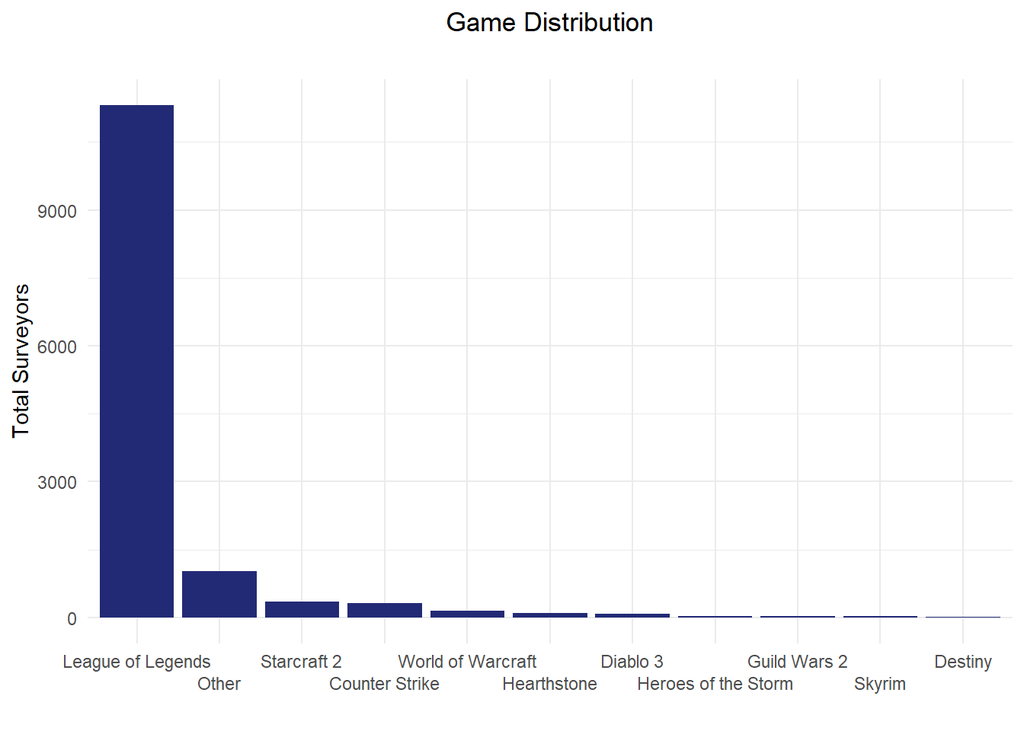

```r
game_counts <- as.data.frame(table(df$Game))
colnames(game_counts) <- c("Game", "SurveyCount")
game_counts <- game_counts[order(-game_counts$SurveyCount), ]

# Create the plot
fig <- ggplot(game_counts, aes(x = reorder(Game, -SurveyCount), y = SurveyCount)) +
  geom_bar(stat = 'identity', fill = '#232A75') +
  labs(title = 'Game Distribution',
       subtitle = '',
       x = '',
       y = 'Total Surveyors') +
  scale_x_discrete(guide = guide_axis(n.dodge = 2)) +
  theme_minimal()  +
 theme(plot.title = element_text(hjust = 0.5))
# Print the figure
print(fig)
```

Gender (cat)

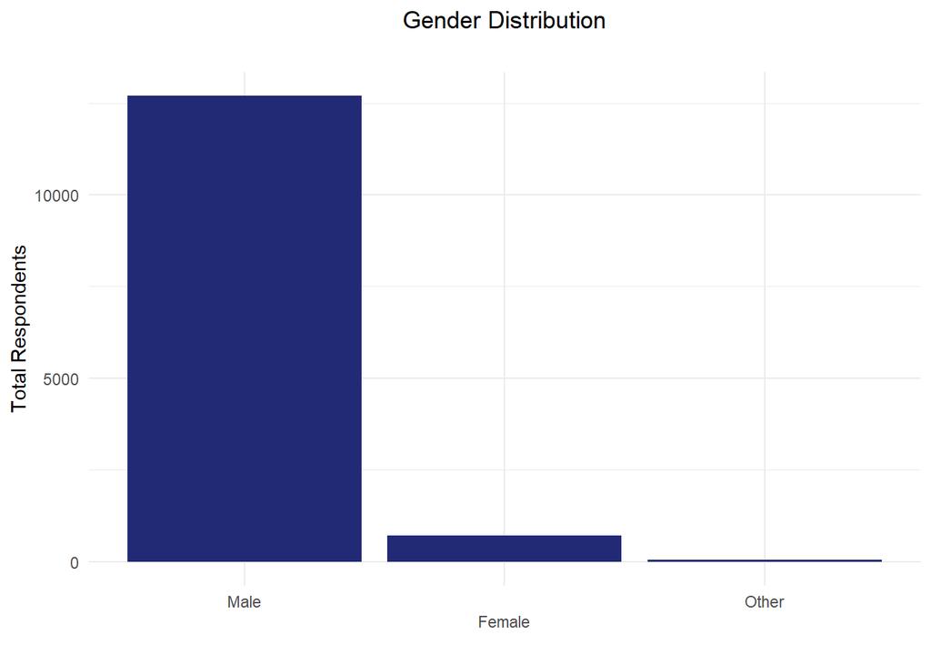

```r
gender_counts <- as.data.frame(table(df$Gender))
colnames(gender_counts) <- c("Gender", "SurveyCount")
gender_counts <- gender_counts[order(-gender_counts$SurveyCount), ]

# Create the plot
fig <- ggplot(gender_counts, aes(x = reorder(Gender, -SurveyCount), y = SurveyCount)) +
  geom_bar(stat = 'identity', fill = '#232A75') +
  labs(title = 'Gender Distribution',
       subtitle = '',
       x = '',
       y = 'Total Respondents') +
  scale_x_discrete(guide = guide_axis(n.dodge = 2)) +
  theme_minimal()  +
 theme(plot.title = element_text(hjust = 0.5))

# Print the figure
print(fig)
```

whyplay

```r
clean_responses <- function(response) {
  response <- trimws(tolower(response))  # Normalize to lowercase and trim whitespace

  # Check for exact matches first
  if (response %in% c("winning", "improving", "relaxing", "having fun")) {
    return(response)
  }

  # Check for various conditions to set the response
  if (str_detect(response, "^a[\\s,\\.]", ) ||
      str_detect(response, "^1[\\s,\\.]", ) ||
      str_detect(response, "^all") ||
      str_detect(response, "^mix") ||
      str_detect(response, "combination") ||
      str_detect(response, "everything")) {
    return("all of the above")
  }

  if (str_detect(response, "distraction|escaping|escape|forget|hide|hiding|depression|boredom|bored|time|forgetting|distracting|doing something|getting away from real life|trying to get my mind off")) {
    return("escape")
  }

  if (str_detect(response, "improve|improving|learn|learning")) {
    return("improving")
  }

  if (str_detect(response, "well|perform|performing")) {
    return("winning")
  }

  if (str_detect(response, "social|socializing|friends|team|cooperating|i don't know anymore|occupied|making my brain go numb|the people i play with, the game is less important")) {
    return("social")
  }

  if (str_detect(response, "win|winning|beating|victory|competeing|competing|competition|conpeting")) {
    return("winning")
  }

  if (str_detect(response, "winning") && str_detect(response, "improving")) {
    return("mix")
  }

  if (str_detect(response, "relaxing") && str_detect(response, "fun")) {
    return("mix")
  }

  if (str_detect(response, "combination|all")) {
    return("mix")
  }

  if (str_detect(response, "fun")) {
    return("having fun")
  }

  # Default to original response if no condition is met
  return("bad response")
}

# Apply the cleaning function to the 'whyplay' column
df$cleaned_whyplay <- sapply(df$whyplay, clean_responses)

# Count the occurrences of each cleaned response
whyplay_counts <- as.data.frame(table(df$cleaned_whyplay))
```

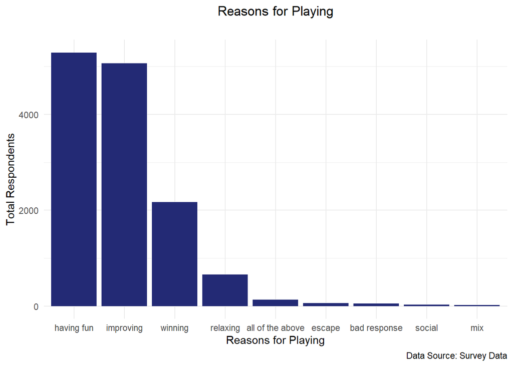

```r
colnames(whyplay_counts) <- c("WhyPlay", "SurveyCount")


whyplay_counts <- whyplay_counts[order(-whyplay_counts$SurveyCount), ]


whyplay_counts$WhyPlay <- factor(whyplay_counts$WhyPlay, levels = whyplay_counts$WhyPlay)


fig <- ggplot(whyplay_counts, aes(x = WhyPlay, y = SurveyCount)) +
  geom_bar(stat = 'identity', fill = '#232A75') +
  labs(title = 'Reasons for Playing',
       subtitle = '',
       caption = 'Data Source: Survey Data',
       x = 'Reasons for Playing',
       y = 'Total Respondents') +
  theme_minimal() +
  theme(plot.title = element_text(hjust = 0.5))


print(fig)
```

Age (num)

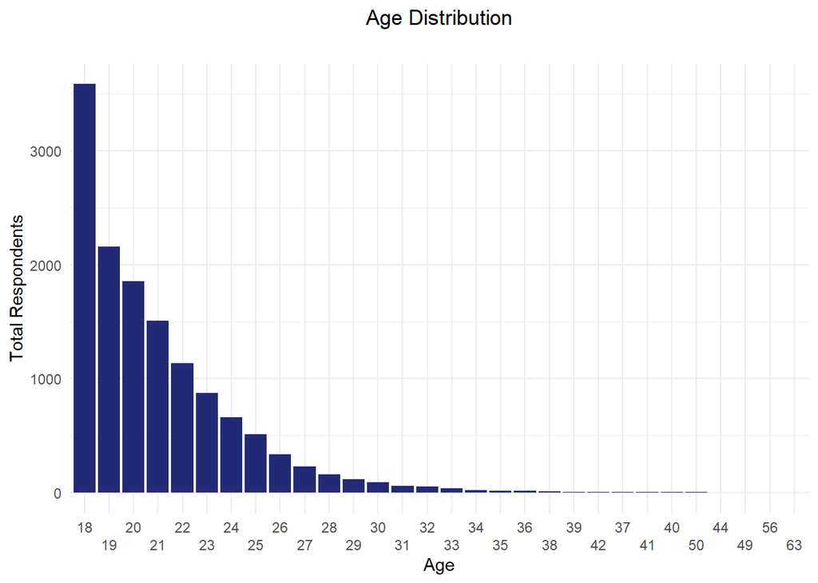

```r
age_counts <- as.data.frame(table(df$Age))
colnames(age_counts) <- c("Age", "SurveyCount")
age_counts <- age_counts[order(-age_counts$SurveyCount), ]

# Create the plot
fig <- ggplot(age_counts, aes(x = reorder(Age, -SurveyCount), y = SurveyCount)) +
  geom_bar(stat = 'identity', fill = '#232A75') +
  labs(title = 'Age Distribution',
       subtitle = '',
       x = 'Age',
       y = 'Total Respondents') +
  scale_x_discrete(guide = guide_axis(n.dodge = 2)) +
  theme_minimal()  +
 theme(plot.title = element_text(hjust = 0.5))

# Print the figure
print(fig)
```

Hours (num)

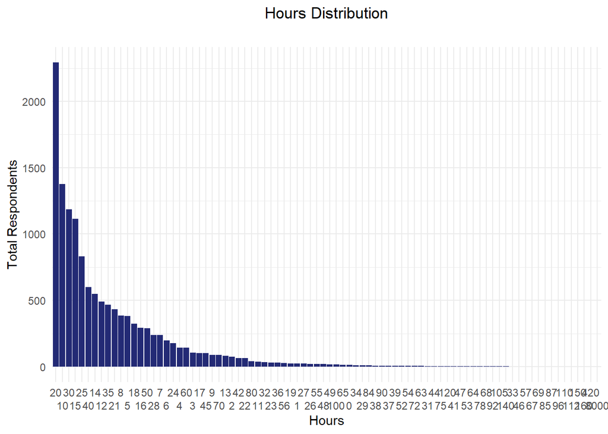

```r
hour_counts <- as.data.frame(table(df$Hours))
colnames(hour_counts) <- c("Hours", "SurveyCount")
hour_counts <- hour_counts[order(-hour_counts$SurveyCount), ]

# Create the plot
fig <- ggplot(hour_counts, aes(x = reorder(Hours, -SurveyCount), y = SurveyCount)) +
  geom_bar(stat = 'identity', fill = '#232A75') +
  labs(title = 'Hours Distribution',
       subtitle = '',
       x = 'Hours',
       y = 'Total Respondents') +
  scale_x_discrete(guide = guide_axis(n.dodge = 2)) +
  theme_minimal()   +
 theme(plot.title = element_text(hjust = 0.5))
# Print the figure
print(fig)
```

streams (num)

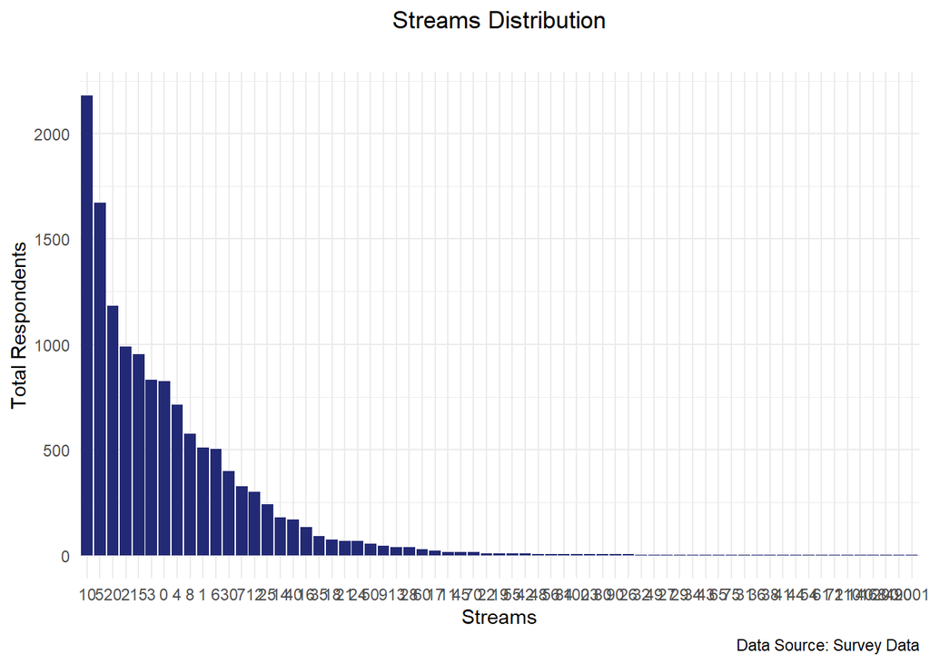

```r
stream_counts <- as.data.frame(table(df$streams))
colnames(stream_counts) <- c("Streams", "SurveyCount")

# Sort the data
stream_counts <- stream_counts[order(-stream_counts$SurveyCount), ]

# Convert Streams to a factor with levels based on sorted order
stream_counts$Streams <- factor(stream_counts$Streams, levels = stream_counts$Streams)

# Create the plot
fig <- ggplot(stream_counts, aes(x = Streams, y = SurveyCount)) +
  geom_bar(stat = 'identity', fill = '#232A75') +
  labs(title = 'Streams Distribution',
       subtitle = '',
       caption = 'Data Source: Survey Data',
       x = 'Streams',
       y = 'Total Respondents') +
  theme_minimal() +
  theme(plot.title = element_text(hjust = 0.5))

# Print the figure
print(fig)
```

## Outliers adn qq

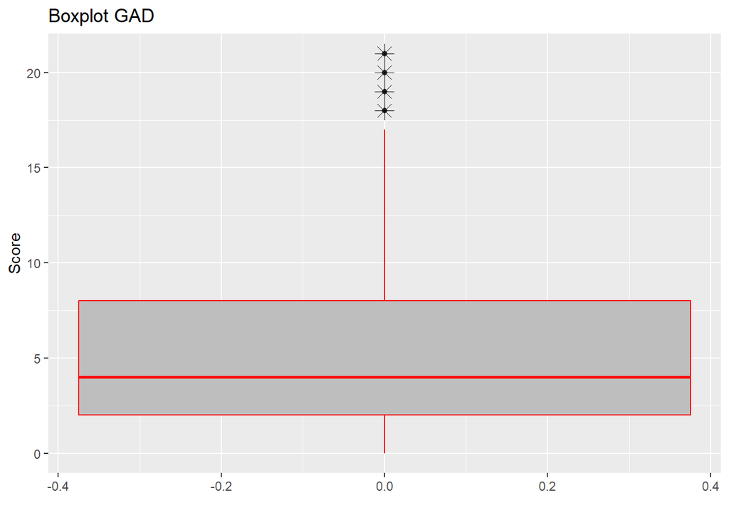

```r
ggplot(df, aes(y=GAD_T)) +
  geom_boxplot() +
  geom_boxplot( colour="red", fill="gray", outlier.colour="black", outlier.shape=8, outlier.size=4) +
  labs(title="Boxplot GAD", x="", y = "Score")
```

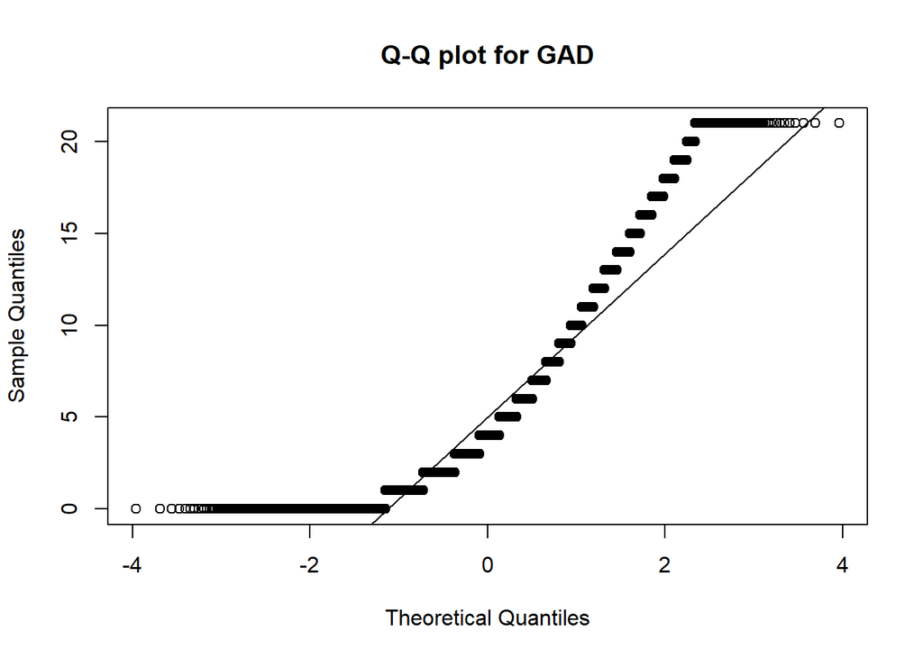

```r
qqnorm(df$GAD_T, main="Q-Q plot for GAD")
qqline(df$GAD_T)
```

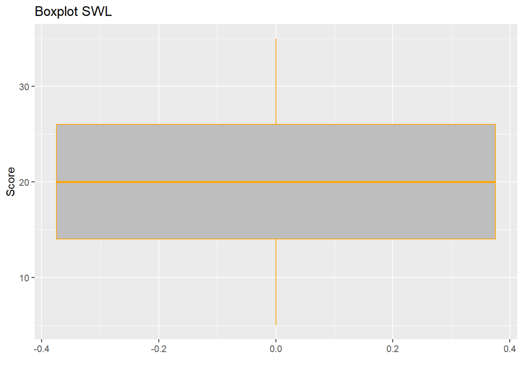

```r
ggplot(df, aes(y=SWL_T)) +
  geom_boxplot() +
  geom_boxplot( colour="orange", fill="gray", outlier.colour="black", outlier.shape=8, outlier.size=4) +
  labs(title="Boxplot SWL", x="", y = "Score")
```

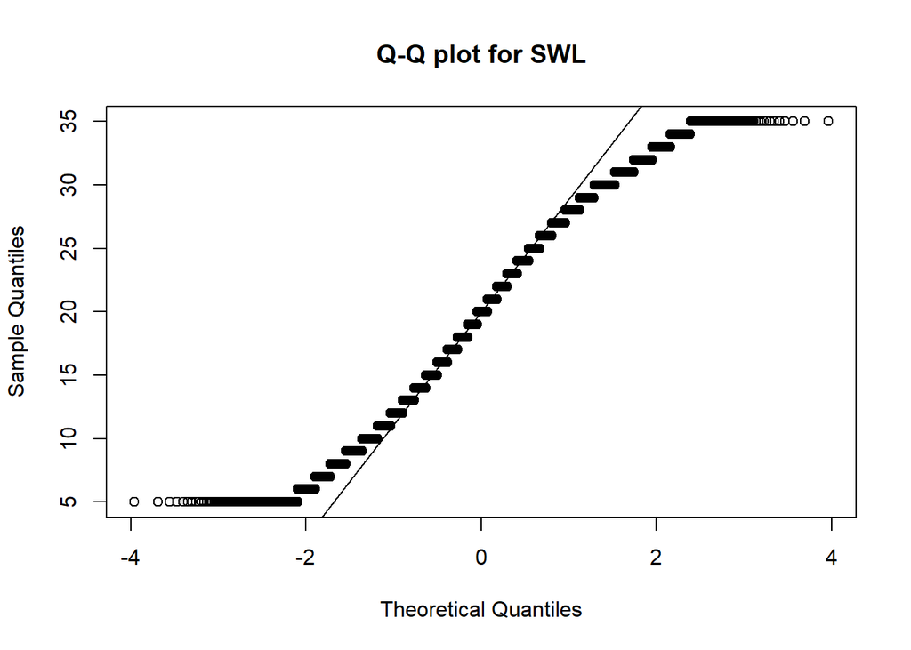

```r
qqnorm(df$SWL_T, main="Q-Q plot for SWL")
qqline(df$SWL_T)
```

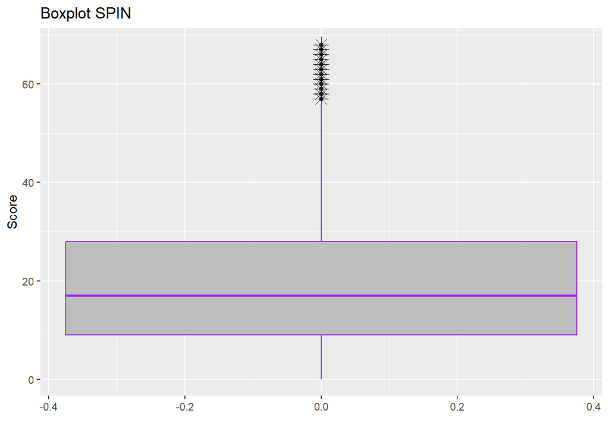

```r
ggplot(df, aes(y=SPIN_T)) +
  geom_boxplot() +
  geom_boxplot( colour="purple", fill="gray", outlier.colour="black", outlier.shape=8, outlier.size=4) +
  labs(title="Boxplot SPIN", x="", y = "Score")
```

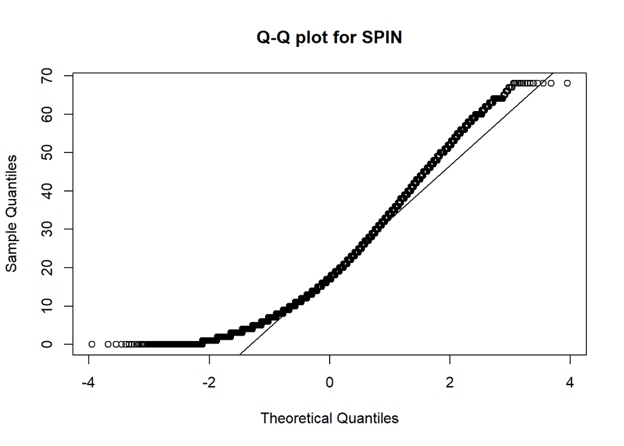

```r
qqnorm(df$SPIN_T, main="Q-Q plot for SPIN")
qqline(df$SPIN_T)
```

## EDA Plots

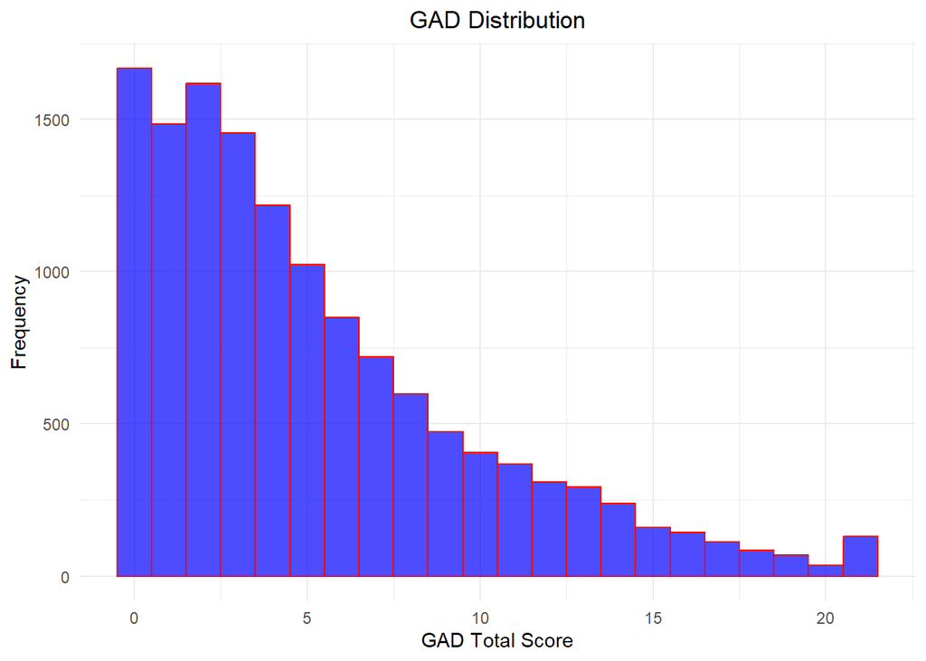

```r
ggplot(data = df, aes(x = GAD_T)) +
  geom_histogram(binwidth = 1,
                 color = "red",
                 fill = "blue",
                 alpha = .7) + # opacity
  labs(x = "GAD Total Score", y = "Frequency", title = "GAD Distribution") +
  theme_minimal() +
  theme(plot.title = element_text(hjust = 0.5))
```

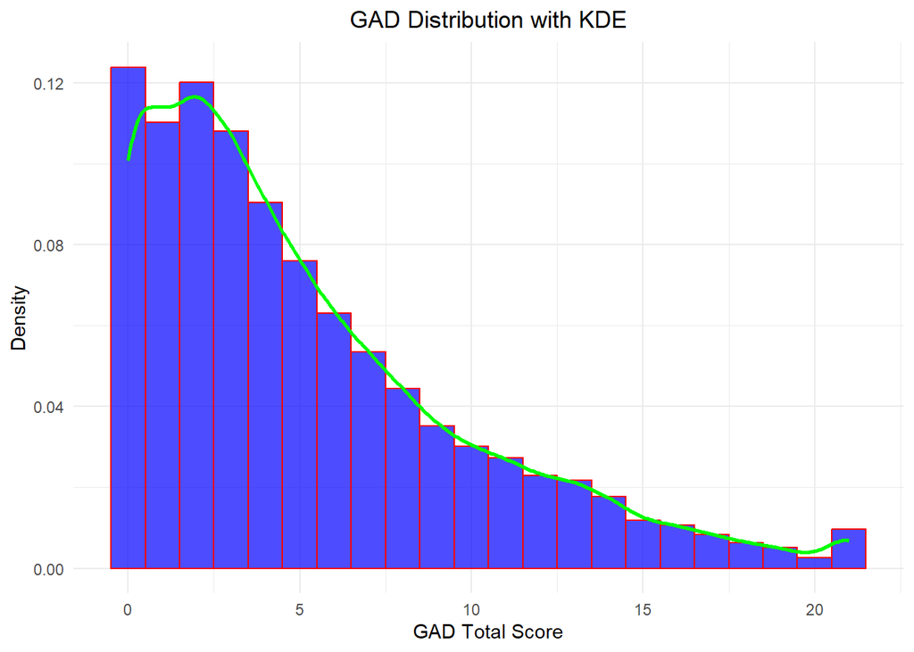

```r
ggplot(data = df, aes(x = GAD_T)) +
  geom_histogram(aes(y = ..density..),  # Use density for y-axis
                 binwidth = 1,
                 color = "red",
                 fill = "blue",
                 alpha = 0.7) +  # Opacity
  geom_density(color = "green",          # Color of the KDE curve
               size = 1,                 # Thickness of the curve
               adjust = 1) +             # Adjust bandwidth for fitting
  labs(x = "GAD Total Score",
       y = "Density",                 # Change to Density for y-axis
       title = "GAD Distribution with KDE") +
  theme_minimal() +
  theme(plot.title = element_text(hjust = 0.5))
```

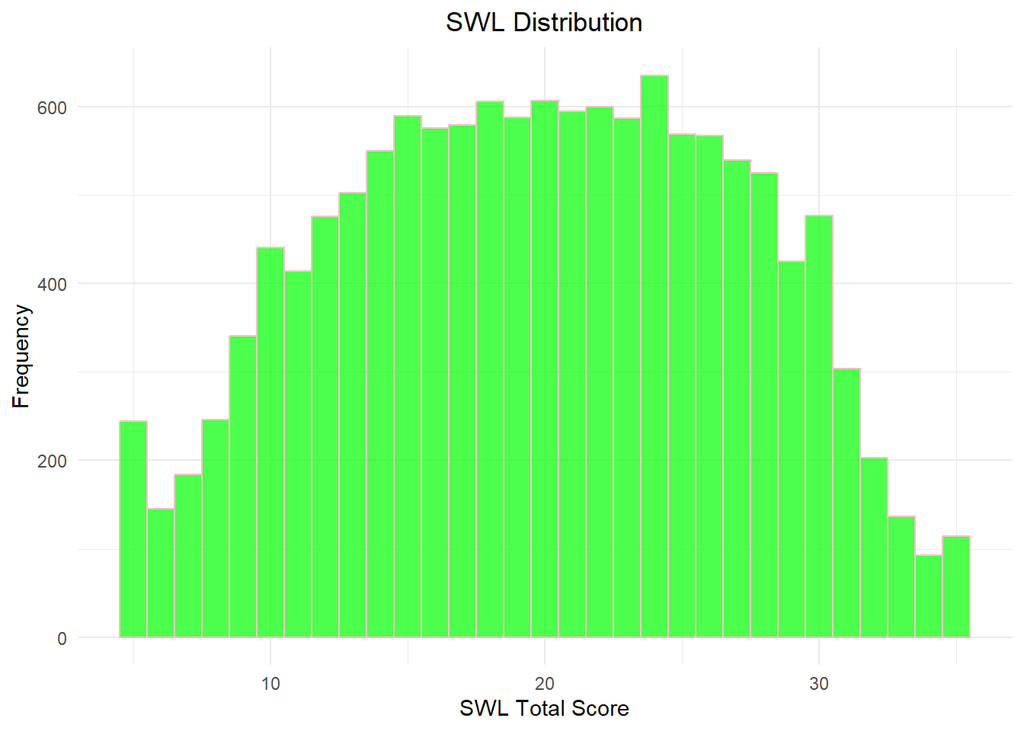

```r
ggplot(data = df, aes(x = SWL_T)) +
  geom_histogram(binwidth = 1,
                 color = "pink",
                 fill = "green",
                 alpha = .7) + # opacity
  labs(x = "SWL Total Score", y = "Frequency", title = "SWL Distribution") +
  theme_minimal() +
  theme(plot.title = element_text(hjust = 0.5))
```

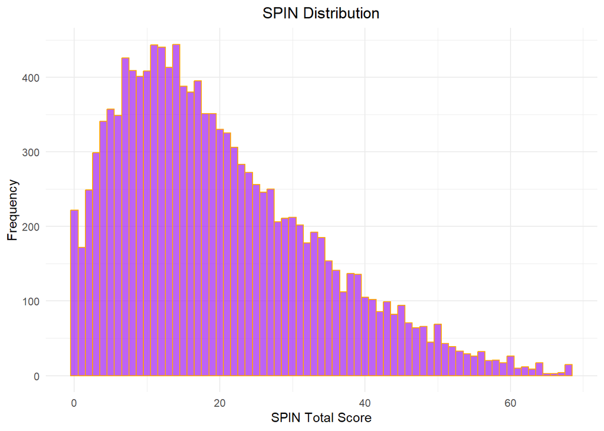

```r
ggplot(data = df, aes(x = SPIN_T)) +
  geom_histogram(binwidth = 1,
                 color = "orange",
                 fill = "purple",
                 alpha = .7) + # opacity
  labs(x = "SPIN Total Score", y = "Frequency", title = "SPIN Distribution") +
  theme_minimal() +
  theme(plot.title = element_text(hjust = 0.5))
```

#### Applying log transform to GAD and SPIN to make them more normal

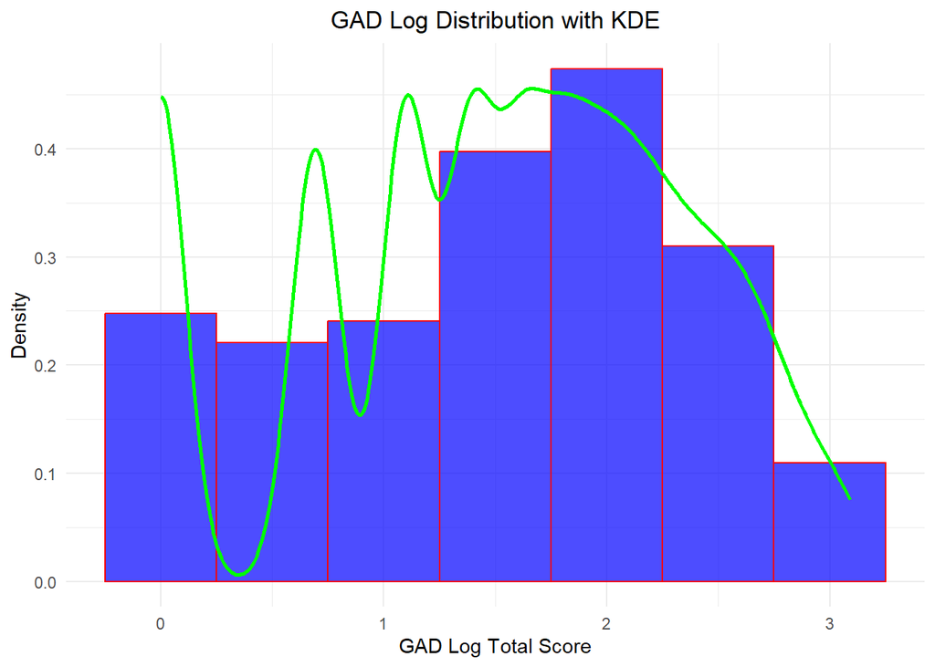

```r
# Log-transform the GAD_T column (adding 1 to avoid log(0))
df$log_GAD_T <- log(df$GAD_T + 1)

# Create the histogram with a KDE curve
ggplot(data = df, aes(x = log_GAD_T)) +
  geom_histogram(aes(y = ..density..),  # Use density for y-axis
                 binwidth = 0.5,
                 color = "red",
                 fill = "blue",
                 alpha = 0.7) +  # Opacity
  geom_density(color = "green",           # Color of the KDE curve
               size = 1,                  # Thickness of the curve
               adjust = 1) +              # Adjust bandwidth for fitting
  labs(x = "GAD Log Total Score",
       y = "Density",                   # Change to Density for y-axis
       title = "GAD Log Distribution with KDE") +
  theme_minimal() +
  theme(plot.title = element_text(hjust = 0.5))
```

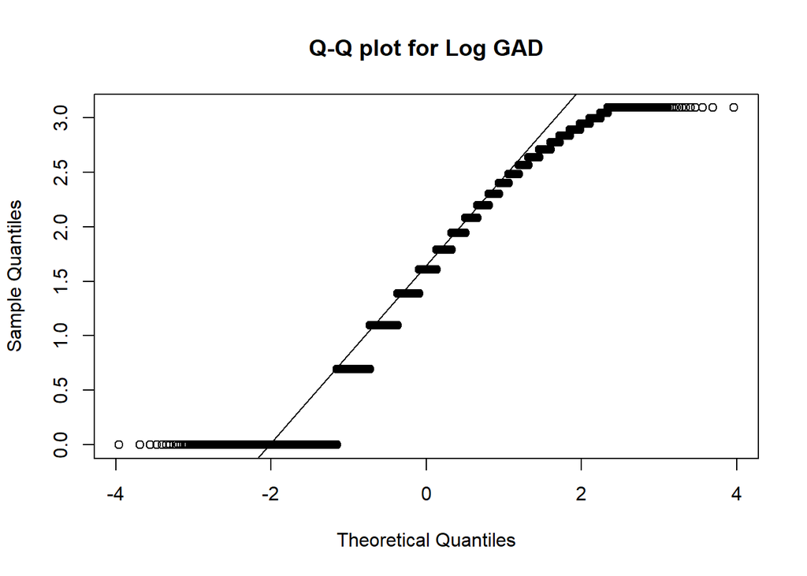

```r
qqnorm(df$log_GAD_T, main="Q-Q plot for Log GAD")
qqline(df$log_GAD_T)
```

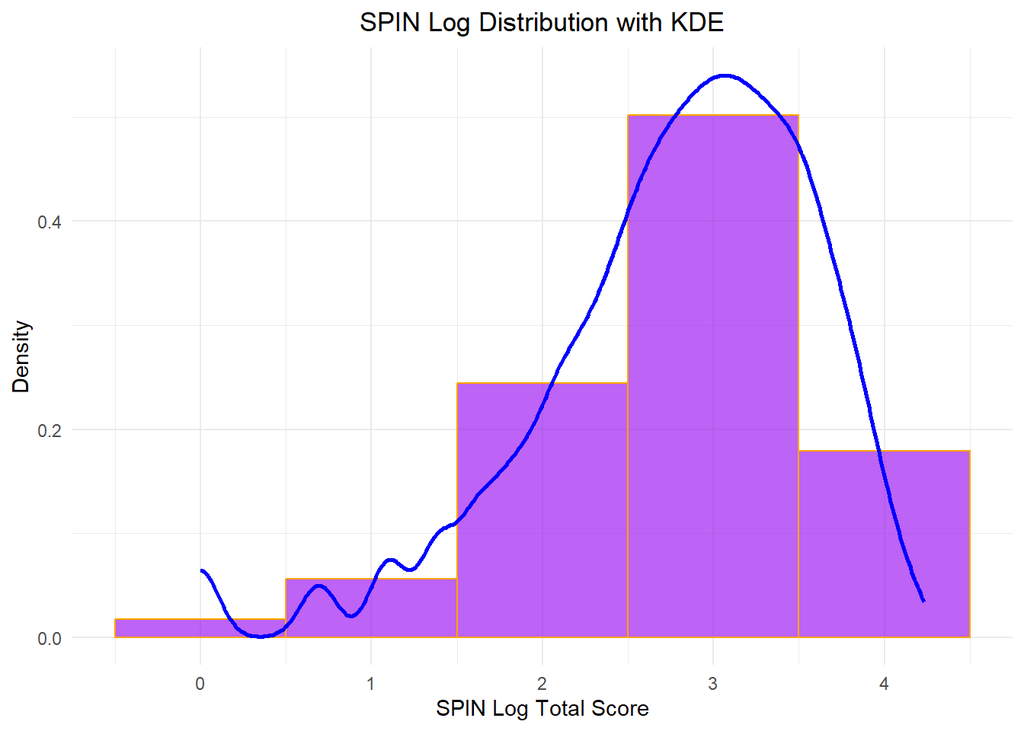

```r
# Log-transform the SPIN_T column (adding 1 to avoid log(0))
df$log_SPIN_T <- log(df$SPIN_T + 1)

# Create the histogram with a KDE curve
ggplot(data = df, aes(x = log_SPIN_T)) +
  geom_histogram(aes(y = ..density..),  # Use density for y-axis
                 binwidth = 1,
                 color = "orange",
                 fill = "purple",
                 alpha = 0.7) +  # Opacity
  geom_density(color = "blue",           # Color of the KDE curve
               size = 1,                 # Thickness of the curve
               adjust = 1) +             # Adjust bandwidth for fitting
  labs(x = "SPIN Log Total Score",
       y = "Density",                  # Change to Density for y-axis
       title = "SPIN Log Distribution with KDE") +
  theme_minimal() +
  theme(plot.title = element_text(hjust = 0.5))
```

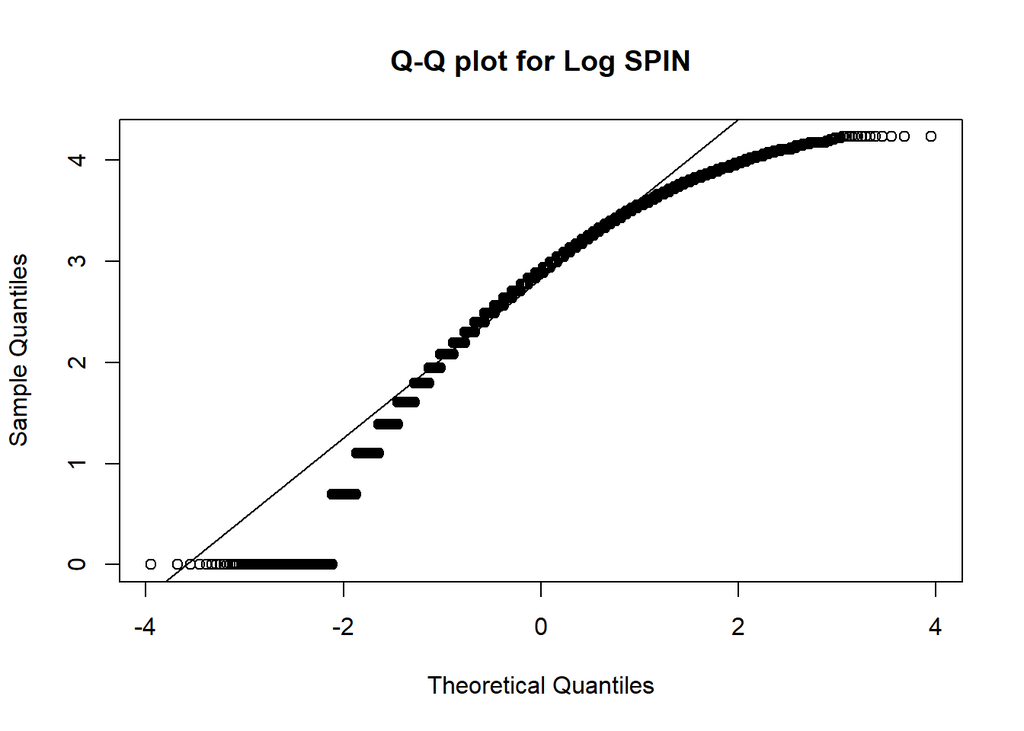

```r
qqnorm(df$log_SPIN_T, main="Q-Q plot for Log SPIN")
qqline(df$log_SPIN_T)
```

```r
# boxplot(mlb$height, main="Boxplot of Baseball Player Height", ylab="Height (inches)", col = 'red' )
# ggplot(mlb, aes(y=height)) +
#   geom_boxplot() +
#   geom_boxplot( colour="orange", fill="#7777cc", outlier.colour="red", outlier.shape=8, outlier.size=4) +
#   labs(title="Boxplot of Baseball Player Height using `ggplot`", x="", y = "Height (inches)")
```

```r
# qqnorm(mlb$height, main="Q-Q plot of Baseball Player Heights")
# qqline(mlb$height)
# shapiro.test(mlb$height) # Shapiro-Wilk test for normality
# ks.test(mlb$height,pnorm) # Kolmogorov-Smirnov Tests against normal distribution
```

## Standardizing

```r
df$GAD_T_Stand <- scale(df$GAD_T)
df$SWL_T_Stand <- scale(df$SWL_T)
df$SPIN_T_Stand <- scale(df$SPIN_T)
```

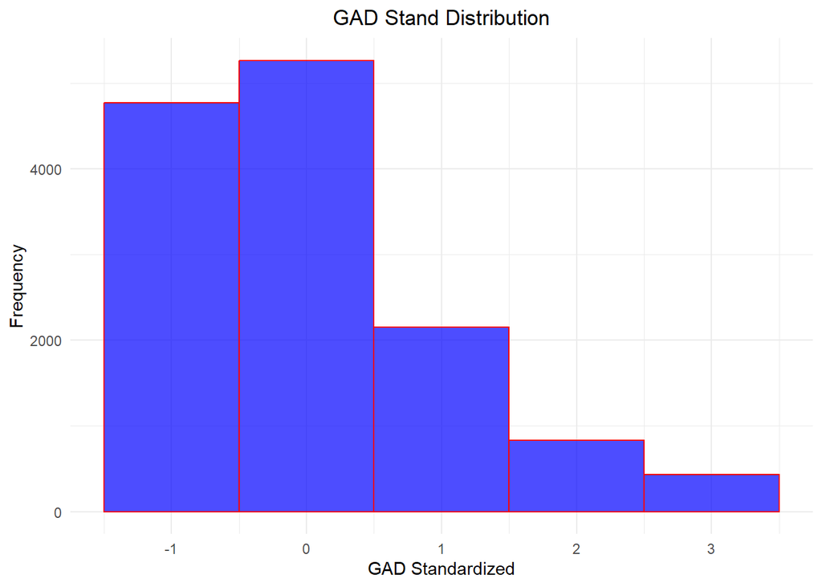

```r
ggplot(data = df, aes(x = GAD_T_Stand)) +
  geom_histogram(binwidth = 1,
                 color = "red",
                 fill = "blue",
                 alpha = .7) + # opacity
  labs(x = "GAD Standardized", y = "Frequency", title = "GAD Stand Distribution") +
  theme_minimal() +
  theme(plot.title = element_text(hjust = 0.5))
```

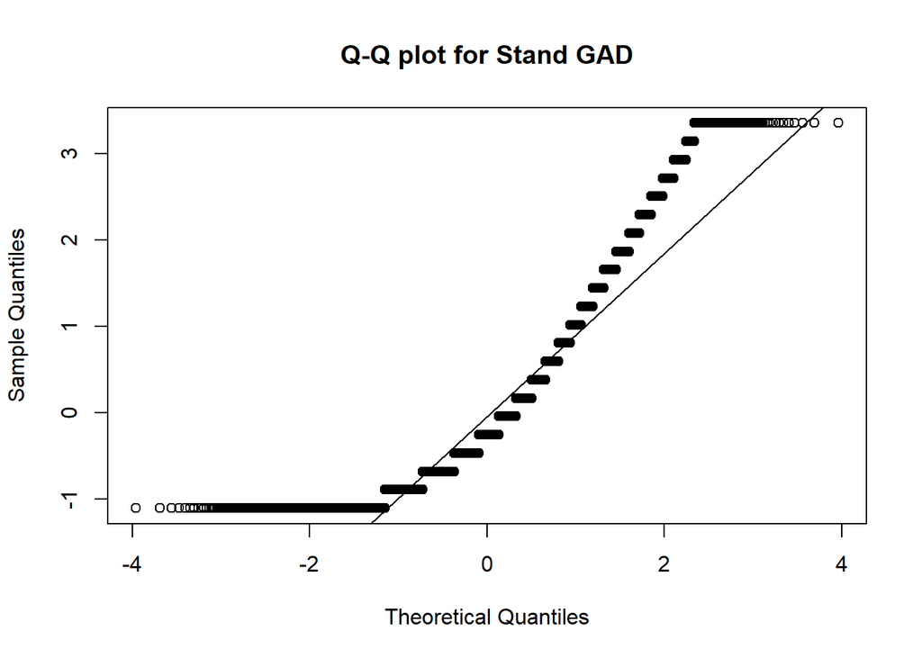

```r
qqnorm(df$GAD_T_Stand, main="Q-Q plot for Stand GAD")
qqline(df$GAD_T_Stand)
```

[figure not shown]

```r
# Create the histogram with a KDE curve
ggplot(data = df, aes(x = SWL_T_Stand)) +
  geom_histogram(aes(y = ..density..),  # Use density for y-axis
                 binwidth = 1,
                 color = "orange",
                 fill = "purple",
                 alpha = 0.7) +  # Opacity
  geom_density(color = "blue",           # Color of the KDE curve
               size = 1,                 # Thickness of the curve
               adjust = 1) +             # Adjust bandwidth for fitting
  labs(x = "GAD Stand Log Total Score",
       y = "Density",                  # Change to Density for y-axis
       title = "GAD Stand Distribution with KDE") +
  theme_minimal() +
  theme(plot.title = element_text(hjust = 0.5))
```

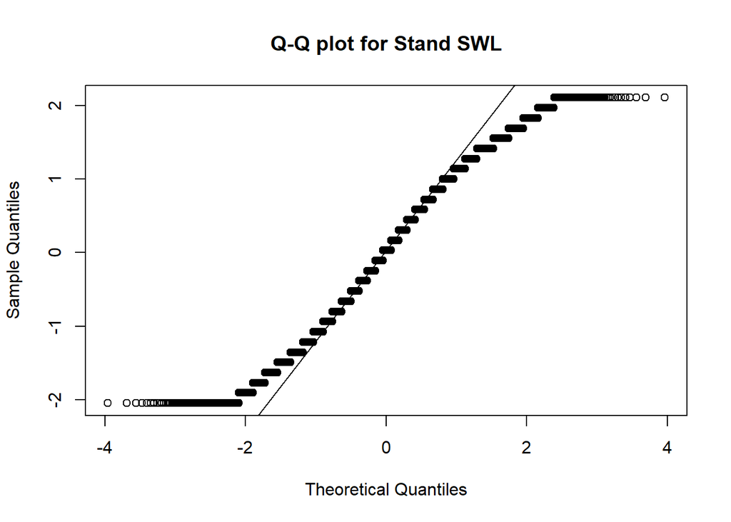

```r
qqnorm(df$SWL_T_Stand, main="Q-Q plot for Stand SWL")
qqline(df$SWL_T_Stand)
```

[figure not shown]

```r
# Create the histogram with a KDE curve
ggplot(data = df, aes(x = SPIN_T_Stand)) +
  geom_histogram(aes(y = ..density..),  # Use density for y-axis
                 binwidth = 1,
                 color = "orange",
                 fill = "purple",
                 alpha = 0.7) +  # Opacity
  geom_density(color = "blue",           # Color of the KDE curve
               size = 1,                 # Thickness of the curve
               adjust = 1) +             # Adjust bandwidth for fitting
  labs(x = "GAD Stand Log Total Score",
       y = "Density",                  # Change to Density for y-axis
       title = "GAD Stand Distribution with KDE") +
  theme_minimal() +
  theme(plot.title = element_text(hjust = 0.5))
```

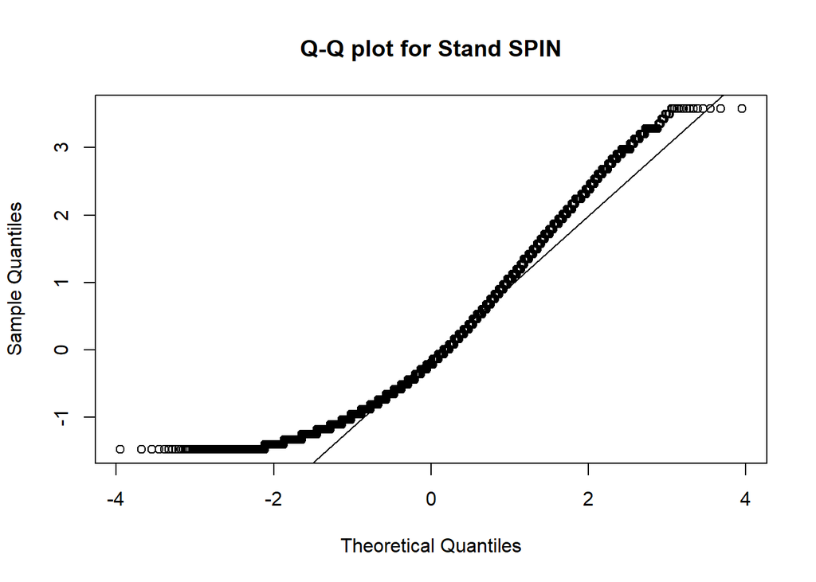

```r
qqnorm(df$SPIN_T_Stand, main="Q-Q plot for Stand SPIN")
qqline(df$SPIN_T_Stand)
```

```r
mean_spin = mean(df$SPIN_T_Stand, na.rm = TRUE)
mean_spin
```

```
## [1] -1.93e-17
```

## Pearsons Corrleation

### SWL and Hours…for now

```r
correlation_result <- cor(df$Hours, df$SWL_T, method = "pearson", use = "complete.obs")
print(correlation_result)
```

```
## [1] -0.0358
```

```r
cor_test <- cor.test(df$Hours, df$SWL_T)
cor_test
```

```
##
##  Pearson's product-moment correlation
##
## data:  df$Hours and df$SWL_T
## t = -4, df = 13432, p-value = 3e-05
## alternative hypothesis: true correlation is not equal to 0
## 95 percent confidence interval:
##  -0.0526 -0.0189
## sample estimates:
##     cor
## -0.0358
```

This very weak negative correlation means that an increase in hours played slightly results in a lower SWL score (less life satisfaction).

### hours and streams

```r
correlation_result <- cor(df$Hours, df$streams, method = "pearson", use = "complete.obs")
print(correlation_result)
```

```
## [1] 0.976
```

```r
cor_test <- cor.test(df$Hours, df$streams)
cor_test
```

```
##
##  Pearson's product-moment correlation
##
## data:  df$Hours and df$streams
## t = 519, df = 13342, p-value <2e-16
## alternative hypothesis: true correlation is not equal to 0
## 95 percent confidence interval:
##  0.975 0.977
## sample estimates:
##   cor
## 0.976
```

## chi-squared

### chi-squared for GAD and WhyPlay

null hypothesis is that there is no relation. Alternate is that there is.

```r
contingency_table <- table(df$GAD_ord, df$cleaned_whyplay)

# Print the contingency table
print(contingency_table)
```

```
##
##                    all of the above bad response escape having fun improving
##   minimal anxiety                78           28     11       3249      2732
##   mild anxiety                   33           17     10       1296      1477
##   moderate anxiety               11            4     22        528       596
##   severe anxiety                  9            3     14        220       263
##
##                     mix relaxing social winning
##   minimal anxiety    11      292     14    1031
##   mild anxiety        4      201      7     621
##   moderate anxiety    1      113      3     335
##   severe anxiety      1       48      2     179
```

```r
chi_squared_test <- chisq.test(contingency_table)

# Print the results of the Chi-squared test
chi_squared_test
```

```
##
##  Pearson's Chi-squared test
##
## data:  contingency_table
## X-squared = 299, df = 24, p-value <2e-16
```

the very low p-value of 0.0000000000000002 indicates very strong evidence against the null hypothesis. We reject the null

Post-hoc analysis

```r
expected_counts <- chisq.test(contingency_table)$expected

# Calculate residuals
residuals <- contingency_table - expected_counts

# Calculate adjusted residuals
adjusted_residuals <- residuals / sqrt(expected_counts)

# Print adjusted residuals
print(adjusted_residuals)
```

```
##
##                    all of the above bad response  escape having fun improving
##   minimal anxiety            0.6524      -0.1413 -3.6553     5.9481   -1.3365
##   mild anxiety              -0.4469       0.7551 -1.4012    -3.8244    2.6133
##   moderate anxiety          -1.1849      -0.8933  5.8057    -4.2137   -0.4526
##   severe anxiety             0.6749       0.0863  6.1463    -4.1372   -0.9094
##
##                        mix relaxing  social winning
##   minimal anxiety   0.5213  -3.6640 -0.0999 -4.8212
##   mild anxiety     -0.2923   1.7182 -0.0298  1.2863
##   moderate anxiety -0.7264   3.9146 -0.0651  4.6876
##   severe anxiety    0.0693   2.0202  0.4796  5.5133
```

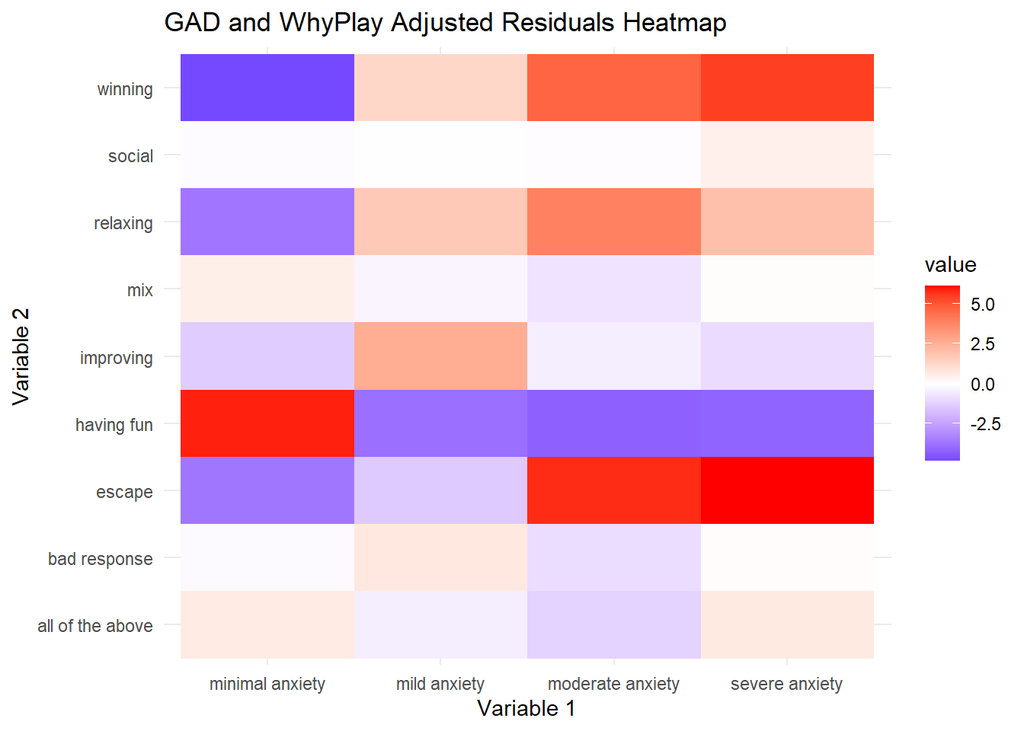

```r
residuals_df <- melt(adjusted_residuals)

# Create a heatmap
ggplot(residuals_df, aes(Var1, Var2, fill = value)) +
  geom_tile() +
  scale_fill_gradient2(low = "blue", mid = "white", high = "red", midpoint = 0) +
  labs(title = "GAD and WhyPlay Adjusted Residuals Heatmap", x = "Variable 1", y = "Variable 2") +
  theme_minimal()
```

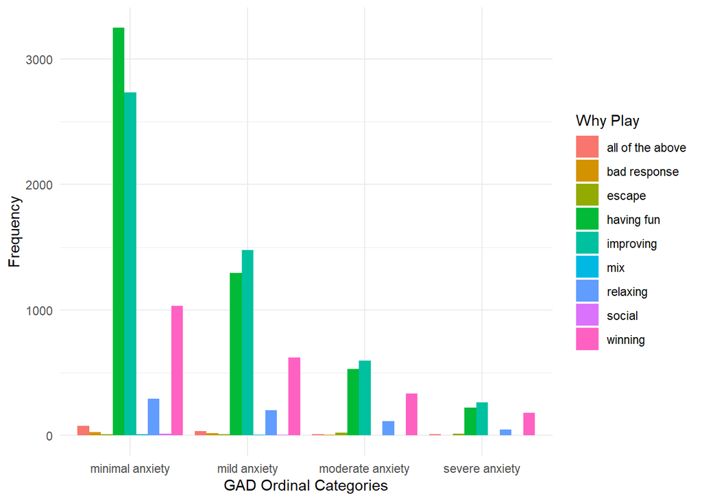

```r
contingency_df <- as.data.frame(contingency_table)

# Plot
ggplot(contingency_df, aes(x = Var1, y = Freq, fill = Var2)) +
  geom_bar(stat = "identity", position = "dodge") +
  labs(x = "GAD Ordinal Categories", y = "Frequency", fill = "Why Play") +
  theme_minimal()
```

### chi-squared for SPIN and WhyPlay

null hypothesis is that there is no relation. Alternate is that there is.

```r
contingency_table <- table(df$SPIN_ord, df$cleaned_whyplay)

# Print the contingency table
print(contingency_table)
```

```
##
##               all of the above bad response escape having fun improving  mix
##   none                      78           27     18       3081      2880   13
##   mild                      23           10      7       1017       981    1
##   moderate                  12            5     11        599       556    1
##   severe                     6            6      5        269       281    0
##   very severe                4            2     12        106       119    0
##
##               relaxing social winning
##   none             357     14    1100
##   mild             128      7     393
##   moderate          77      1     280
##   severe            40      2     169
##   very severe       18      1      97
```

```r
chi_squared_test <- chisq.test(contingency_table)

# Print the results of the Chi-squared test
chi_squared_test
```

```
##
##  Pearson's Chi-squared test
##
## data:  contingency_table
## X-squared = 178, df = 32, p-value <2e-16
```

the very low p-value of 0.0000000000000002 indicates very strong evidence against the null hypothesis. We reject the null

Post-hoc analysis

```r
expected_counts <- chisq.test(contingency_table)$expected

# Calculate residuals
residuals <- contingency_table - expected_counts

# Calculate adjusted residuals
adjusted_residuals <- residuals / sqrt(expected_counts)

# Print adjusted residuals
print(adjusted_residuals)
```

```
##
##               all of the above bad response   escape having fun improving
##   none                 0.62837     -0.46561 -2.37756    1.56137   0.65733
##   mild                -0.33045     -0.00518 -1.11016    0.02941   0.51574
##   moderate            -0.72817     -0.41455  1.83023   -0.45941  -0.98288
##   severe              -0.53716      1.70131  0.99346   -2.21933  -0.67031
##   very severe          0.29844      0.50626  8.62923   -3.02826  -1.37335
##
##                    mix relaxing   social  winning
##   none         1.39125 -0.47944 -0.19911 -3.00389
##   mild        -1.15659  0.34068  0.89003 -0.76536
##   moderate    -0.59921  0.27681 -1.15794  2.21094
##   severe      -0.95432  0.38413  0.39133  4.06262
##   very severe -0.64826  0.15115  0.35798  5.27577
```

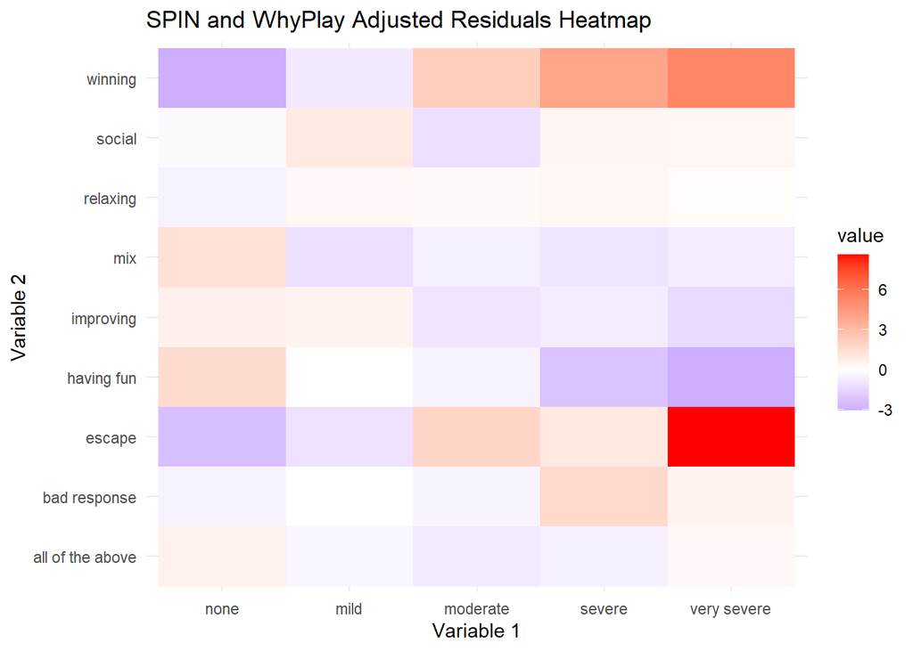

```r
residuals_df <- melt(adjusted_residuals)

# Create a heatmap
ggplot(residuals_df, aes(Var1, Var2, fill = value)) +
  geom_tile() +
  scale_fill_gradient2(low = "blue", mid = "white", high = "red", midpoint = 0) +
  labs(title = "SPIN and WhyPlay Adjusted Residuals Heatmap", x = "Variable 1", y = "Variable 2") +
  theme_minimal()
```

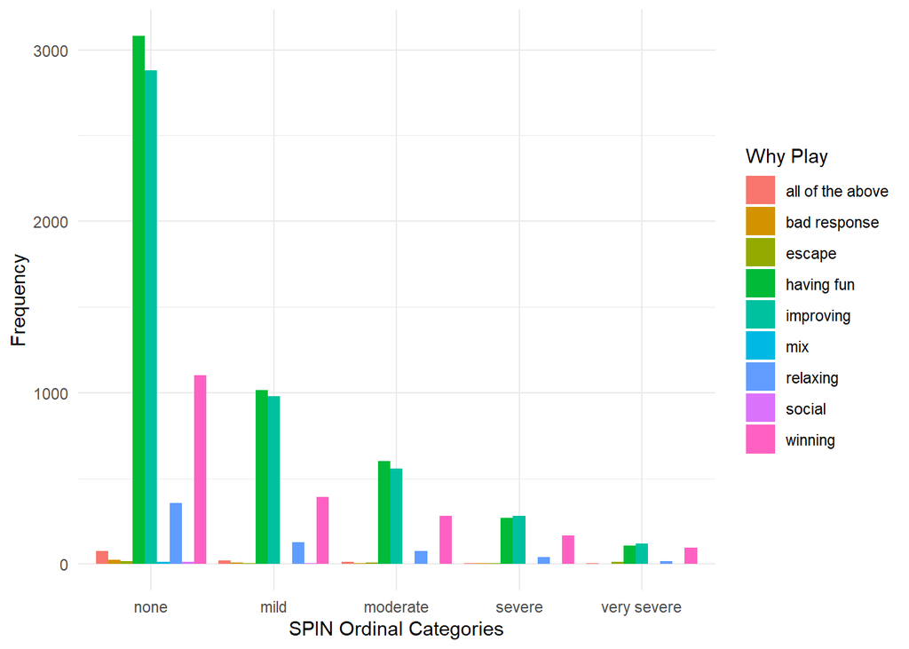

```r
contingency_df <- as.data.frame(contingency_table)

# Plot
ggplot(contingency_df, aes(x = Var1, y = Freq, fill = Var2)) +
  geom_bar(stat = "identity", position = "dodge") +
  labs(x = "SPIN Ordinal Categories", y = "Frequency", fill = "Why Play") +
  theme_minimal()
```

### chi-squared for SWL and WhyPlay

null hypothesis is that there is no relation. Alternate is that there is.

```r
contingency_table <- table(df$SWL_ord, df$cleaned_whyplay)

# Print the contingency table
print(contingency_table)
```

```
##
##                          all of the above bad response escape having fun
##   extremely satisfied                   7            5      0        362
##   satisfied                            25            8      3       1165
##   slightly satisfied                   34           11      5       1256
##   neutral                              10            2      4        238
##   slightly dissatisfied                29           12     10       1115
##   dissatisfied                         18            8     12        828
##   extremely dissatisfied                8            6     23        329
##
##                          improving  mix relaxing social winning
##   extremely satisfied          316    3       34      2     122
##   satisfied                    914    1      106      5     308
##   slightly satisfied          1136    5      128      3     409
##   neutral                      224    0       28      4      97
##   slightly dissatisfied       1100    4      169      4     497
##   dissatisfied                 925    4      121      4     464
##   extremely dissatisfied       453    0       68      4     269
```

```r
chi_squared_test <- chisq.test(contingency_table)

# Print the results of the Chi-squared test
chi_squared_test
```

```
##
##  Pearson's Chi-squared test
##
## data:  contingency_table
## X-squared = 302, df = 48, p-value <2e-16
```

the very low p-value of 0.0000000000000002 indicates very strong evidence against the null hypothesis. We reject the null

Post-hoc analysis

```r
expected_counts <- chisq.test(contingency_table)$expected

# Calculate residuals
residuals <- contingency_table - expected_counts

# Calculate adjusted residuals
adjusted_residuals <- residuals / sqrt(expected_counts)

# Print adjusted residuals
print(adjusted_residuals)
```

```
##
##                          all of the above bad response  escape having fun
##   extremely satisfied             -0.4448       0.9451 -1.8981     1.5009
##   satisfied                        0.0675      -0.5722 -2.3602     5.3355
##   slightly satisfied               0.9159      -0.1579 -2.1500     2.3855
##   neutral                          1.6847      -0.2249  0.8922    -0.0405
##   slightly dissatisfied            0.0738       0.1915 -0.6935    -1.1995
##   dissatisfied                    -1.0788      -0.3979  0.6004    -3.5671
##   extremely dissatisfied          -0.9782       0.7181  8.1628    -5.9482
##
##                          improving     mix relaxing  social winning
##   extremely satisfied      -0.2417  1.8576  -1.1411  0.2782 -1.2737
##   satisfied                -1.3015 -1.2301  -1.5442  0.0473 -4.9427
##   slightly satisfied        0.3477  0.6326  -1.4188 -1.1526 -3.2630
##   neutral                  -0.2965 -0.8755  -0.2734  2.6119 -0.0658
##   slightly dissatisfied    -0.1999  0.1494   2.1918 -0.7040  1.1050
##   dissatisfied              0.9225  0.5706   0.4832 -0.2814  4.1094
##   extremely dissatisfied    0.7831 -1.2102   1.5526  1.1759  6.0310
```

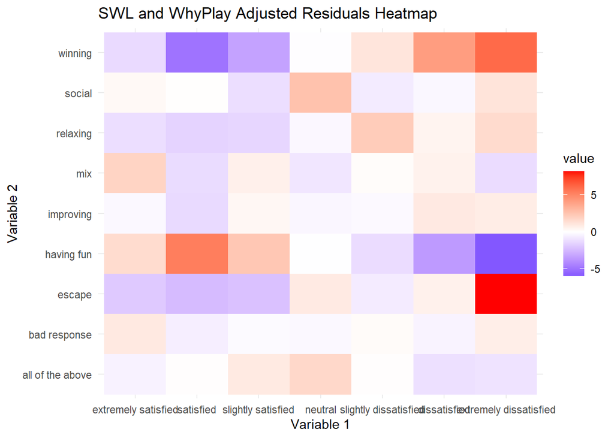

```r
residuals_df <- melt(adjusted_residuals)

# Create a heatmap
ggplot(residuals_df, aes(Var1, Var2, fill = value)) +
  geom_tile() +
  scale_fill_gradient2(low = "blue", mid = "white", high = "red", midpoint = 0) +
  labs(title = "SWL and WhyPlay Adjusted Residuals Heatmap", x = "Variable 1", y = "Variable 2") +
  theme_minimal()
```

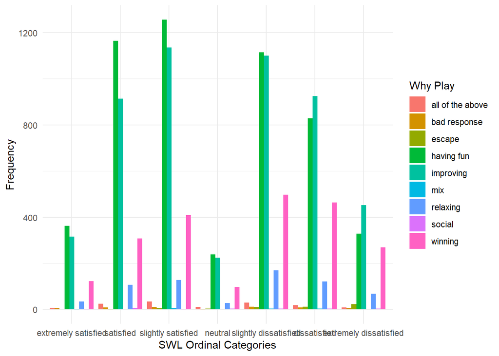

```r
contingency_df <- as.data.frame(contingency_table)

# Plot
ggplot(contingency_df, aes(x = Var1, y = Freq, fill = Var2)) +
  geom_bar(stat = "identity", position = "dodge") +
  labs(x = "SWL Ordinal Categories", y = "Frequency", fill = "Why Play") +
  theme_minimal()
```